# Depression Prediction - Memo

Senior Thesis

Author

Ali Slayie

Published

January 13, 2025

**Github Repo Link**

[Link to Repository](https://github.com/ali3el/alis-thesis.git)

# Introduction

This memo provides an update on the progress of my thesis project, which focuses on understanding the extent to which we can predict whether someone has ever experienced depression in their life based on demographic factors such as sexual orientation, ethnicity, race, and other variables. This work is motivated by my interest in examining disparities among different demographic groups in relation to mental health outcomes, with a specific focus on the mental health of LGBTQ+ migrants. I aim to explore the unique challenges faced by individuals who hold these identities and compare their experiences to those of individuals without these identities or those who hold only one of them. Progress has been made in data preparation, feature engineering, and model development.

# Data Collection and Cleaning

The dataset for this thesis was sourced from the [National Health Interview Survey (NHIS)](https://www.cdc.gov/nchs/nhis/index.html), which provides detailed information on the health, demographic, and socioeconomic characteristics of individuals in the United States. Data from multiple years (2019-2023) were consolidated into a single dataset, resulting in a robust sample of over 100,000 observations.

In the data cleaning process, consistent variable naming conventions were applied across all datasets to ensure uniformity. For example, variables such as `EDUC_A` and `MAXEDUC_A` were renamed to `education_level` and `max_education_level`, respectively, to improve clarity and consistency. Missing columns were added where necessary, and missing values were handled using mode imputation for categorical variables (e.g., imputing the most common value for region) and median imputation for numerical variables (e.g., filling missing values in age with the dataset’s median age).

Additionally, variable types were standardized to align with the requirements of various modeling approaches. For instance, binary variables like `depression_ever` and `anxiety_ever` were converted into factors with levels “Yes” and “No,” while ordinal variables such as `life_satisfaction` were encoded with ordered levels ranging from “Very dissatisfied” to “Very satisfied.” These steps were essential to prepare the dataset for feature engineering and subsequent modeling tasks, ensuring its quality and usability for analysis.

Figure 1 below demonstrates the distribution of the data focus group for this project:

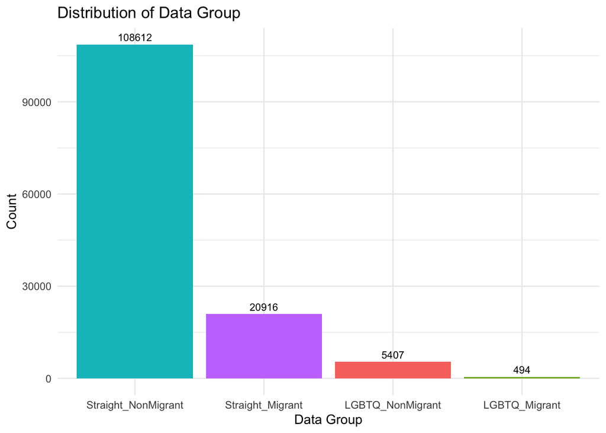

Figure 1: Distribution of Focus Group

## Target Variable Selection and Problem Type

I chose `depression_ever`, a binary variable, as the primary target (outcome) variable. Thus, this is a classification problem. Figure 2 below displays the distribution of the target variable:

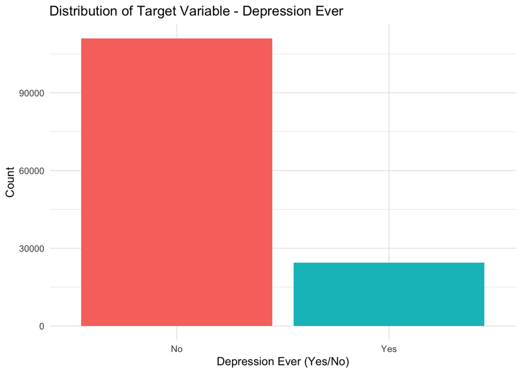

Figure 2: Distribution of Target Variable

# Model Development

## Implemented Models

For this classification problem, I selected models that are both effective for classification and interpretable, aligning with the goals of the thesis. The models implemented so far include K-Nearest Neighbors (KNN), Naive Bayes, Logistic Regression, Decision Trees, and RuleFit. These models were developed and tested using the tidymodels framework, which was utilized for model specification, workflows, and hyperparameter tuning.

## Hyperparameter Tuning

To optimize model performance, I implemented grid search with 5-fold cross-validation. Currently, I am running one repeat of the 5-fold cross-validation to manage computational time, given the size of the dataset (over 100,000 observations). This approach provides a balance between robust model evaluation and runtime efficiency. I plan to increase the number of repeats once runtime challenges are addressed to improve model performance and reliability.

## Challenges

The main challenge encountered during this stage is the significant runtime required for model training and hyperparameter tuning, given the large dataset and complexity of 5-fold cross-validation. Although parallel processing has been implemented to improve runtime efficiency, training remains time-consuming. To address this, I am exploring computational alternatives such as running models on high-performance servers or utilizing cloud-based solutions.

# Feature Engineering and Recipe Development

To prepare the dataset for model training and to explore different preprocessing strategies, I developed two distinct preprocessing pipelines (recipes): one for “kitchen sink” models that include all available variables, and another for feature-engineered models focused on selected demographic predictors.

## Kitchen Sink Recipes

The kitchen sink recipes were designed to utilize all variables in the dataset, maximizing the information available for model training. These recipes are suitable for exploring the potential of all predictors and identifying key variables. Two versions were created:

### Non-Tree (Parametric) Models

This recipe includes steps for imputing missing values (mode for categorical variables, median for numeric), handling novel levels, creating dummy variables for categorical predictors, removing zero-variance predictors, and normalizing all predictors to align with parametric model assumptions.

### Tree (Non-Parametric) Models

While tree-based models are less sensitive to scaling and normalization, this recipe includes one-hot encoding for categorical variables, ensuring compatibility with the modeling framework. Steps to handle missing values, novel levels, and zero-variance predictors are also included.

These recipes enable the models to evaluate the impact of all available predictors without prior feature selection, providing a baseline for model performance.

## Feature-Engineered Recipes

To investigate specific research hypotheses and improve model interpretability, I developed feature-engineered recipes focusing on selected demographic predictors, including:

- data_group (a composite variable combining sexual_orientation and nativity_status)
- Geographic variables: `region`, `urban_rural`
- Demographic variables: `race_category`, `age`, `sex`
- Ethnic variables: `hispanic_ethnicity`, `hispanic_and_race`, `hispanic_details`

These recipes were tailored for both `parametric` and `non-parametric` models:

### Parametric Models:

This recipe includes imputation, normalization, and dummy variable creation to meet the assumptions of parametric models.

### Non-Parametric Models:

Similar to the parametric recipe, but utilizes one-hot encoding for categorical variables and excludes normalization. The feature-engineered recipes aim to examine the relationships between mental health outcomes and key demographic variables while maintaining computational efficiency by reducing the number of predictors.

# Results

The results of the models’ performances are summarized in the tables below:

## Kitchen Sink Recipe

Models such as Logistic Regression, RuleFit, and Decision Tree showed high performance, with Decision Tree achieving the highest mean accuracy of 0.9036. However, KNN and Naive Bayes, while still effective, performed slightly lower with a mean accuracy of 0.8748 and 0.8197, respectively as seen in Table 1.

Table 1: Accuracy of Kitchen Sink Recipe Based Models

| model | mean | std_err | n |
| --- | --- | --- | --- |
| Naive Bayes KS | 0.8196930 | 0.0000020 | 5 |
| KNN KS | 0.8747681 | 0.0008847 | 5 |
| Logistic KS | 0.9023195 | 0.0005645 | 5 |
| RuleFit KS | 0.9024302 | 0.0009583 | 5 |
| Decision Tree KS | 0.9035655 | 0.0013013 | 5 |

## Feature-Engineering Recipe (M1)

The selective feature recipe showed slightly lower overall accuracy across models compared to the Kitchen Sink recipe. The best-performing models were Logistic Regression (0.8219) and Decision Tree (0.8218) as seen in Table 2. Naive Bayes and RuleFit also demonstrated competitive accuracy.

Table 2: Accuracy of Feature Engineered Recipe Based Models

| model | mean | std_err | n |
| --- | --- | --- | --- |
| KNN M1 | 0.8187239 | 0.0005024 | 5 |
| Naive Bayes M1 | 0.8196930 | 0.0000020 | 5 |
| RuleFit M1 | 0.8207452 | 0.0003191 | 5 |
| Decision Tree M1 | 0.8218621 | 0.0001826 | 5 |
| Logistic M1 | 0.8219728 | 0.0003692 | 5 |

## Discussion

Accuracy Trends: While the Kitchen Sink recipe leveraged the full breadth of data, it also introduced potential noise from less relevant features. This explains the slight performance drop in the selective recipe for models such as Logistic Regression and Decision Trees.

### Model Insights:

- Logistic Regression consistently performed well, benefiting from its parametric nature and ability to generalize from smaller feature sets.
- Decision Trees and RuleFit demonstrated robustness, suggesting their suitability for capturing complex patterns in both recipes.
- Naive Bayes showed stable performance but was outperformed by other methods, likely due to its independence assumption.
- KNN, being sensitive to feature scaling, performed better with the Kitchen Sink recipe but had reduced accuracy in the selective recipe

# Next Steps

The following is what I hope to do next in this project:

- Develop additional recipes with advanced feature engineering (EDA-influenced, transformations like log transformations, etc..)
- Refine hyperparameter tuning for top-performing models
- Focus on the explainability and interpretation of the best-performing model using tools like LIME and SHAP
- Analyze results for deeper insights into mental health and how the results compare to those of journal articles
- Since the LGBTQ+ population is significantly smaller than their straight counterparts, I may consider reducing the size of the dataset by downsampling the majority population. This may contribute to shorter running times